# Projet Jedha - Conversion rate

```python
import numpy as np
import pandas as pd
import matplotlib.pyplot as plt
import seaborn as sns
import warnings

warnings.filterwarnings('ignore')
```

```python
dataset = pd.read_csv("conversion_data.csv")
```

## 1. Descriptive part

Overview

Dataset info

| Number of variables | 6 |
| --- | --- |
| Number of observations | 316200 |
| Total Missing (%) | 0.0% |
| Total size in memory | 14.5 MiB |
| Average record size in memory | 48.0 B |

Variables types

| Numeric | 2 |
| --- | --- |
| Categorical | 2 |
| Boolean | 2 |
| Date | 0 |
| Text (Unique) | 0 |
| Rejected | 0 |
| Unsupported | 0 |

Warnings

- Dataset has 299903 duplicate rows Warning

Variables

age  
Numeric

| Distinct count | 60 |
| --- | --- |
| Unique (%) | 0.0% |
| Missing (%) | 0.0% |
| Missing (n) | 0 |
| Infinite (%) | 0.0% |
| Infinite (n) | 0 |

| Mean | 30.57 |
| --- | --- |
| Minimum | 17 |
| Maximum | 123 |
| Zeros (%) | 0.0% |

Toggle details

**Statistics**

Quantile statistics

| Minimum | 17 |
| --- | --- |
| 5-th percentile | 18 |
| Q1 | 24 |
| Median | 30 |
| Q3 | 36 |
| 95-th percentile | 45 |
| Maximum | 123 |
| Range | 106 |
| Interquartile range | 12 |

Descriptive statistics

| Standard deviation | 8.2718 |
| --- | --- |
| Coef of variation | 0.27059 |
| Kurtosis | -0.032363 |
| Mean | 30.57 |
| MAD | 6.7358 |
| Skewness | 0.51932 |
| Sum | 9666189 |
| Variance | 68.423 |
| Memory size | 2.4 MiB |

**Histogram**

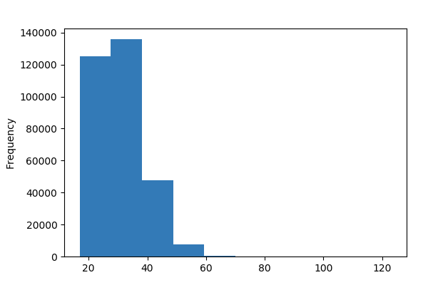

**Common Values**

| Value | Count | Frequency (%) |  |
| --- | --- | --- | --- |
| 30 | 14346 | 4.5% |  |
| 28 | 14341 | 4.5% |  |
| 29 | 14158 | 4.5% |  |
| 27 | 14084 | 4.5% |  |
| 26 | 13931 | 4.4% |  |
| 31 | 13692 | 4.3% |  |
| 32 | 13507 | 4.3% |  |
| 25 | 13460 | 4.3% |  |
| 24 | 12960 | 4.1% |  |
| 33 | 12631 | 4.0% |  |
| Other values (50) | 179090 | 56.6% |  |

**Extreme Values**

Minimum 5 values

| Value | Count | Frequency (%) |  |
| --- | --- | --- | --- |
| 17 | 7597 | 2.4% |  |
| 18 | 8466 | 2.7% |  |
| 19 | 9349 | 3.0% |  |
| 20 | 10156 | 3.2% |  |
| 21 | 10966 | 3.5% |  |

Maximum 5 values

| Value | Count | Frequency (%) |  |
| --- | --- | --- | --- |
| 73 | 1 | 0.0% |  |
| 77 | 1 | 0.0% |  |
| 79 | 1 | 0.0% |  |
| 111 | 1 | 0.0% |  |
| 123 | 1 | 0.0% |  |

converted  
Boolean

| Distinct count | 2 |
| --- | --- |
| Unique (%) | 0.0% |
| Missing (%) | 0.0% |
| Missing (n) | 0 |

| Mean | 0.032258 |
| --- | --- |

| 0 | 306000 |
| --- | --- |
| 1 | 10200 |

Toggle details

| Value | Count | Frequency (%) |  |
| --- | --- | --- | --- |
| 0 | 306000 | 96.8% |  |
| 1 | 10200 | 3.2% |  |

country  
Categorical

| Distinct count | 4 |
| --- | --- |
| Unique (%) | 0.0% |
| Missing (%) | 0.0% |
| Missing (n) | 0 |

| US | 178092 |
| --- | --- |
| China | 76602 |
| UK | 48450 |

Toggle details

| Value | Count | Frequency (%) |  |
| --- | --- | --- | --- |
| US | 178092 | 56.3% |  |
| China | 76602 | 24.2% |  |
| UK | 48450 | 15.3% |  |
| Germany | 13056 | 4.1% |  |

new_user  
Boolean

| Distinct count | 2 |
| --- | --- |
| Unique (%) | 0.0% |
| Missing (%) | 0.0% |
| Missing (n) | 0 |

| Mean | 0.68546 |
| --- | --- |

| 1 | 216744 |
| --- | --- |
| 0 | 99456 |

Toggle details

| Value | Count | Frequency (%) |  |
| --- | --- | --- | --- |
| 1 | 216744 | 68.5% |  |
| 0 | 99456 | 31.5% |  |

source  
Categorical

| Distinct count | 3 |
| --- | --- |
| Unique (%) | 0.0% |
| Missing (%) | 0.0% |
| Missing (n) | 0 |

| Seo | 155040 |
| --- | --- |
| Ads | 88740 |
| Direct | 72420 |

Toggle details

| Value | Count | Frequency (%) |  |
| --- | --- | --- | --- |
| Seo | 155040 | 49.0% |  |
| Ads | 88740 | 28.1% |  |
| Direct | 72420 | 22.9% |  |

total_pages_visited  
Numeric

| Distinct count | 29 |
| --- | --- |
| Unique (%) | 0.0% |
| Missing (%) | 0.0% |
| Missing (n) | 0 |
| Infinite (%) | 0.0% |
| Infinite (n) | 0 |

| Mean | 4.873 |
| --- | --- |
| Minimum | 1 |
| Maximum | 29 |
| Zeros (%) | 0.0% |

Toggle details

**Statistics**

Quantile statistics

| Minimum | 1 |
| --- | --- |
| 5-th percentile | 1 |
| Q1 | 2 |
| Median | 4 |
| Q3 | 7 |
| 95-th percentile | 11 |
| Maximum | 29 |
| Range | 28 |
| Interquartile range | 5 |

Descriptive statistics

| Standard deviation | 3.3411 |
| --- | --- |
| Coef of variation | 0.68564 |
| Kurtosis | 3.2085 |
| Mean | 4.873 |
| MAD | 2.541 |
| Skewness | 1.4428 |
| Sum | 1540832 |
| Variance | 11.163 |
| Memory size | 2.4 MiB |

**Histogram**

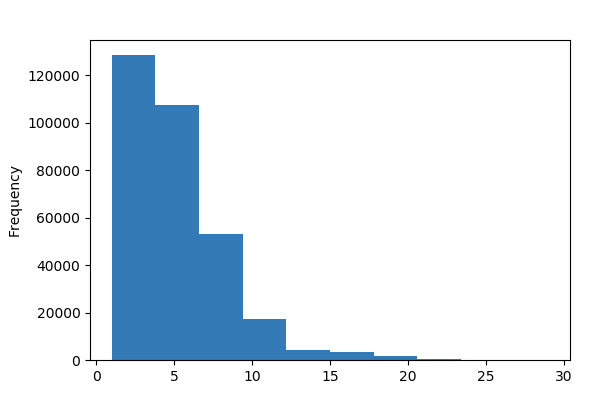

**Common Values**

| Value | Count | Frequency (%) |  |
| --- | --- | --- | --- |
| 2 | 43868 | 13.9% |  |
| 3 | 43829 | 13.9% |  |
| 4 | 41046 | 13.0% |  |
| 1 | 40739 | 12.9% |  |
| 5 | 36308 | 11.5% |  |
| 6 | 30261 | 9.6% |  |
| 7 | 23488 | 7.4% |  |
| 8 | 17522 | 5.5% |  |
| 9 | 12157 | 3.8% |  |
| 10 | 8074 | 2.6% |  |
| Other values (19) | 18908 | 6.0% |  |

**Extreme Values**

Minimum 5 values

| Value | Count | Frequency (%) |  |
| --- | --- | --- | --- |
| 1 | 40739 | 12.9% |  |
| 2 | 43868 | 13.9% |  |
| 3 | 43829 | 13.9% |  |
| 4 | 41046 | 13.0% |  |
| 5 | 36308 | 11.5% |  |

Maximum 5 values

| Value | Count | Frequency (%) |  |
| --- | --- | --- | --- |
| 25 | 39 | 0.0% |  |
| 26 | 17 | 0.0% |  |
| 27 | 7 | 0.0% |  |
| 28 | 1 | 0.0% |  |
| 29 | 2 | 0.0% |  |

Correlations

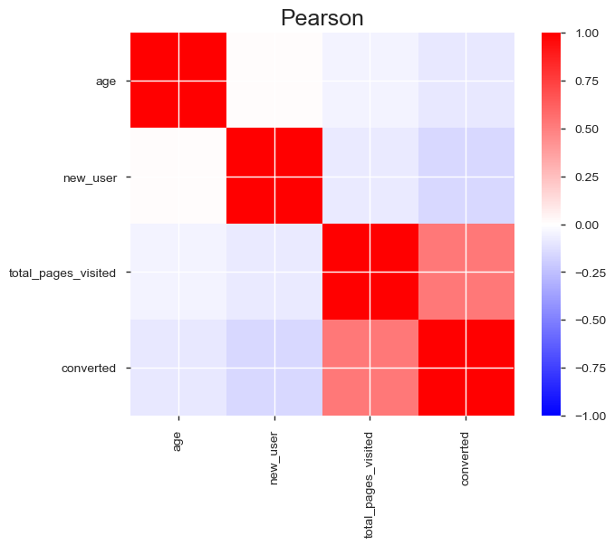

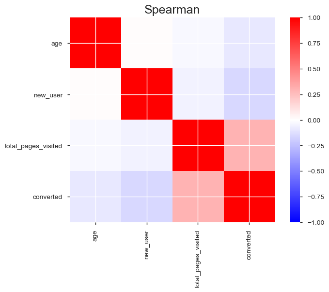

Sample

|  | country | age | new_user | source | total_pages_visited | converted |
| --- | --- | --- | --- | --- | --- | --- |
| 0 | UK | 25 | 1 | Ads | 1 | 0 |
| 1 | US | 23 | 1 | Seo | 5 | 0 |
| 2 | US | 28 | 1 | Seo | 4 | 0 |
| 3 | China | 39 | 1 | Seo | 5 | 0 |
| 4 | US | 30 | 1 | Seo | 6 | 0 |

```python
import pandas_profiling
profile = pandas_profiling.ProfileReport(dataset)
profile
```

```python
dataset.isnull().any()
```

```
country                False
age                    False
new_user               False
source                 False
total_pages_visited    False
converted              False
dtype: bool
```

```python
dataset.describe(percentiles = [i for i in np.arange(1,step=0.1)])
```

|  | age | new_user | total_pages_visited | converted |
| --- | --- | --- | --- | --- |
| count | 316200.000000 | 316200.000000 | 316200.000000 | 316200.000000 |
| mean | 30.569858 | 0.685465 | 4.872966 | 0.032258 |
| std | 8.271802 | 0.464331 | 3.341104 | 0.176685 |
| min | 17.000000 | 0.000000 | 1.000000 | 0.000000 |
| 0% | 17.000000 | 0.000000 | 1.000000 | 0.000000 |
| 10% | 20.000000 | 0.000000 | 1.000000 | 0.000000 |
| 20% | 23.000000 | 0.000000 | 2.000000 | 0.000000 |
| 30.0% | 25.000000 | 0.000000 | 3.000000 | 0.000000 |
| 40% | 28.000000 | 1.000000 | 3.000000 | 0.000000 |
| 50% | 30.000000 | 1.000000 | 4.000000 | 0.000000 |
| 60.0% | 32.000000 | 1.000000 | 5.000000 | 0.000000 |
| 70% | 35.000000 | 1.000000 | 6.000000 | 0.000000 |
| 80% | 38.000000 | 1.000000 | 7.000000 | 0.000000 |
| 90% | 42.000000 | 1.000000 | 9.000000 | 0.000000 |
| max | 123.000000 | 1.000000 | 29.000000 | 1.000000 |

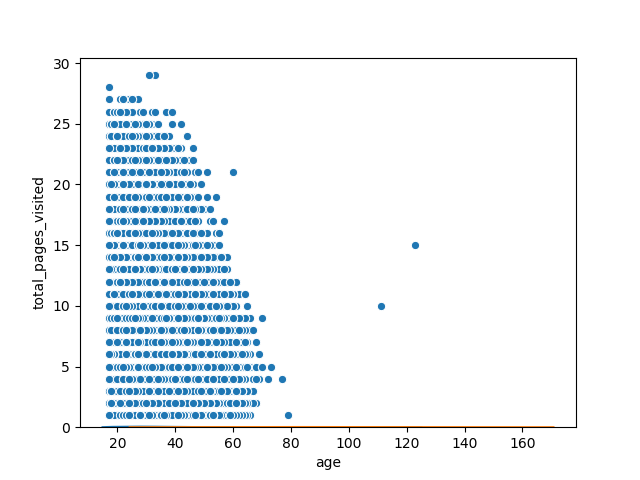

```python
sns.scatterplot(x= "age", y= "total_pages_visited", data= dataset)
```

Plus il y a de pages visitees et plus il est probable que la personne soit jeune

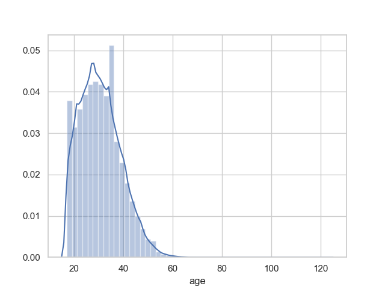

```python
sns.distplot(dataset.age)
```

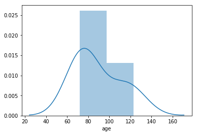

```python
sns.distplot(dataset[dataset.age > 70].age )
```

On supprime les outliers age > 70

```python
dataset = dataset[dataset.age<70]
```

[figure not shown]

```python
g = sns.set(style="whitegrid")
g, ax= plt.subplots(1, figsize=(15,6))
sns.pointplot(x="age", y="converted", data=dataset, logistic=True, ci=None)
```

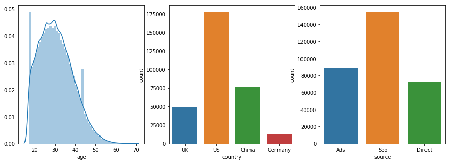

```python
f, ax = plt.subplots(1,3, figsize=(15,5))
sns.distplot(dataset.age, ax=ax[0])
sns.countplot(dataset.country, ax = ax[1])
sns.countplot(dataset.source, ax = ax[2])
```

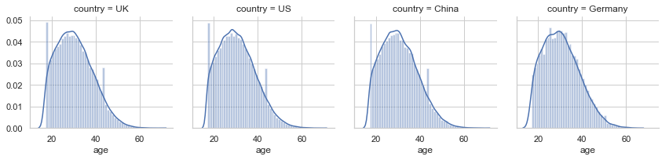

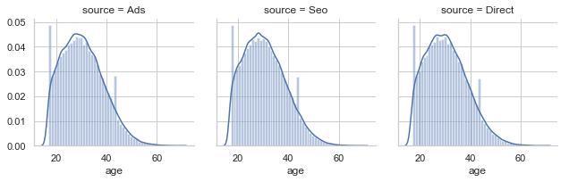

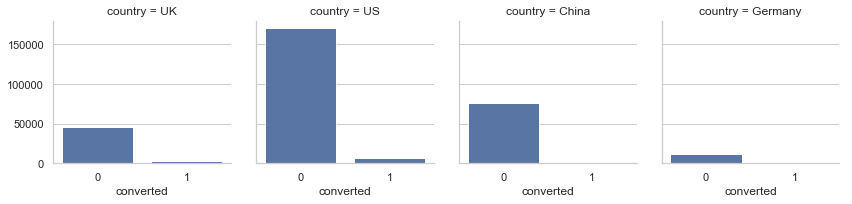

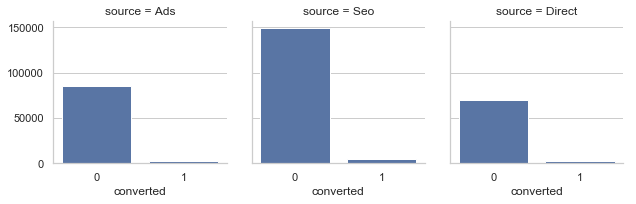

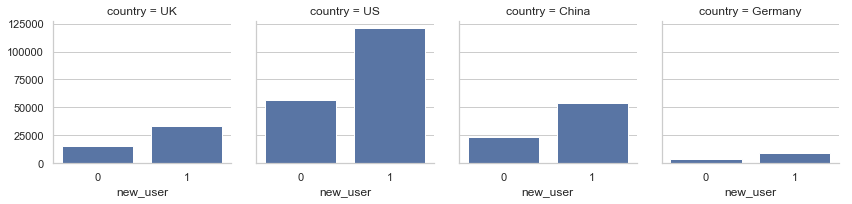

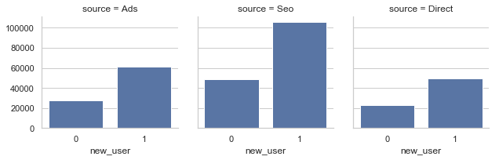

```python
FG1 = sns.FacetGrid(data = dataset, col = "country")
FG1.map(sns.distplot, "age")

FG2 = sns.FacetGrid(data = dataset, col = "source")
FG2.map(sns.distplot,"age")

FG3 = sns.FacetGrid(data = dataset, col = "country")
FG3.map(sns.countplot,"converted")
FG4 = sns.FacetGrid(data = dataset, col = "source")
FG4.map(sns.countplot, "converted" )

FG5 = sns.FacetGrid(data = dataset, col = "country")
FG5.map(sns.countplot, "new_user" )
FG5 = sns.FacetGrid(data = dataset, col = "source")
FG5.map(sns.countplot, 'new_user')
```

```python
dataset.groupby(by="country" ).mean()
```

| country | age | new_user | total_pages_visited | converted |
| --- | --- | --- | --- | --- |
| China | 30.672972 | 0.698520 | 4.553523 | 0.001332 |
| Germany | 30.442895 | 0.677288 | 5.189966 | 0.062428 |
| UK | 30.449059 | 0.679863 | 5.082067 | 0.052613 |
| US | 30.565257 | 0.681981 | 4.930169 | 0.037802 |

On categorise l'age

```python
dataset_cat_age = dataset.copy()
dataset_cat_age.loc[:,"age"] = dataset.age.apply(lambda x:
                 "17-22" if x <23 else
                 "23-28" if x <29 else
                 "29-34" if x <35 else
                 "35-42" if x <43 else
                 "43-48" if x <49 else
                 ">49")
```

Visualisation du dataset pour mieux comprendre de quoi il en retourne

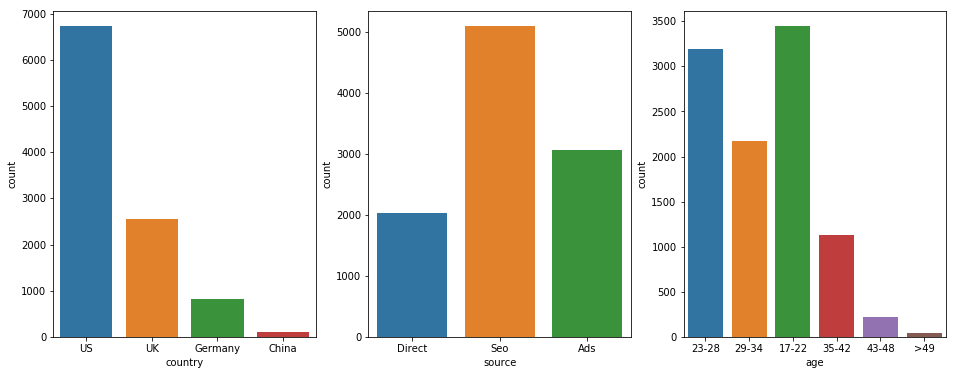

```python
f, ax = plt.subplots(1,3, figsize=(16,6))
sns.countplot(dataset_cat_age[dataset_cat_age.converted ==1].country, ax=ax[0])
sns.countplot(dataset_cat_age[dataset_cat_age.converted ==1].source, ax=ax[1])
sns.countplot(dataset_cat_age[dataset_cat_age.converted ==1].age, ax=ax[2])
```

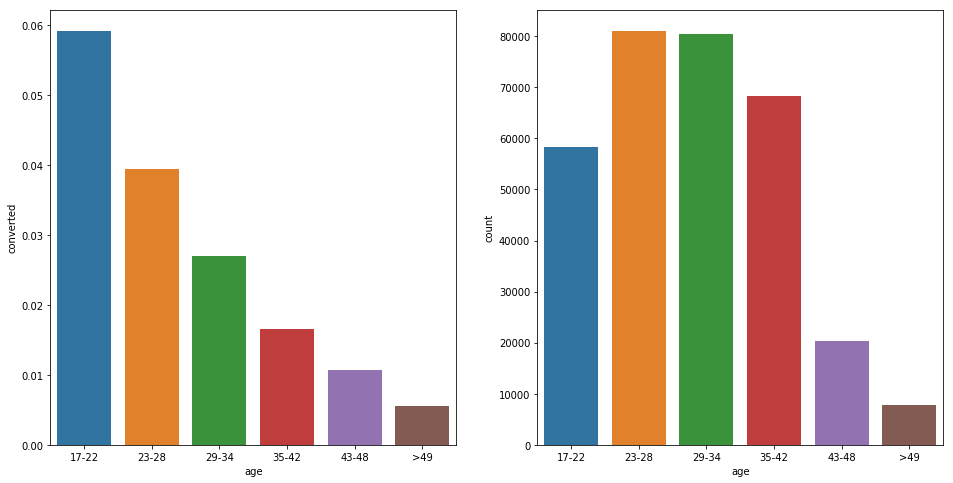

```python
f, ax = plt.subplots(1,2, figsize = (16,8))
conversion_rate_per_age = dataset_cat_age.converted.groupby(dataset_cat_age.age).sum() / dataset_cat_age.converted.groupby(dataset_cat_age.age).count()
conversion_rate_per_age
sns.barplot(x= conversion_rate_per_age.index, y= conversion_rate_per_age, ax = ax[0])
sns.countplot(dataset_cat_age.age.sort_values(), ax = ax[1])
```

#### Takeaway

Il semble qu'il existe une relation ressemblant a une relation lineaire entre la categorie d'age et le taux de conversion => recommandations possibles (dependant de l'objectif strategique et des moyens a disposition)

- Focaliser les efforts sur les plus jeunes pour optimiser les chances de conversion (eg envoyer du marketing cible aux 17-22 qui ont le plus fort taux de conversion) OU
- Actionner les leviers pour ameliorer la conversion des 23-42 qui sont tres nombreux a venir sur le site mais avec un taux de conversion plus faible que les 17-22. Exemple : changer le produit / le site pour mieux repondre a cette categorie d'age

On fait la meme analyse rapide par source et par Pays

Par source

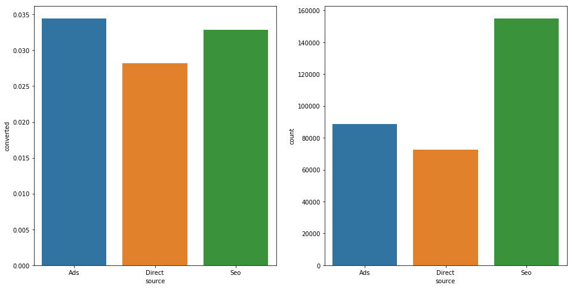

```python
f, ax = plt.subplots(1,2, figsize = (16,8))
conversion_rate_per_source = dataset_cat_age.converted.groupby(dataset_cat_age.source).sum() / dataset_cat_age.converted.groupby(dataset_cat_age.source).count()

sns.barplot(x= conversion_rate_per_source.index, y= conversion_rate_per_source, ax = ax[0])
sns.countplot(dataset_cat_age.source.sort_values(), ax = ax[1])
```

#### Takeaway :

Les trois sources ont un taux de conversion assez homogene, Direct source etant legerement en dessous es deux autres. En fonction du cout de chaque canal, une reduction de cout peut etre opere en investissant plus sur le moins couteux. (a voir bien evidement s'il n'y a pas d'effet de seuil, ie. un point a partir duquel le gain marginal en visiteurs de chaque euro supplementaire depense se reduit considerablement

Par Pays

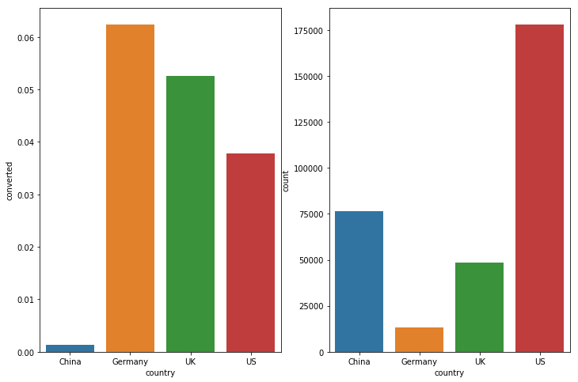

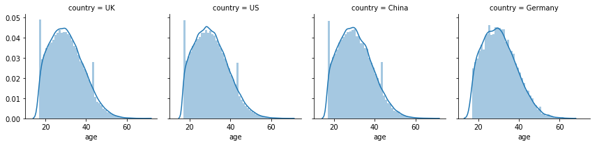

```python
f, ax = plt.subplots(1,2, figsize = (12,8))
conversion_rate_per_country = dataset_cat_age.converted.groupby(dataset_cat_age.country).sum() / dataset_cat_age.converted.groupby(dataset_cat_age.country).count()

sns.barplot(x= conversion_rate_per_country.index, y= conversion_rate_per_country, ax = ax[0])
sns.countplot(dataset_cat_age.country.sort_values(), ax = ax[1])
FG1 = sns.FacetGrid(data = dataset, col = "country")
FG1.map(sns.distplot, "age")
```

#### Takeaway

On voit que l'allemagne et le UK ont les taux de conversion les plus eleves a respectivement c.6% et c.5% alors que ce sont deux pays avec le plus faible nombre de visiteurs. La distribution d'age assez homogenes pour chaque pays indique que ce taux de conversion superieur n'est pas tire par une population plus jeune provenant de ces pays. Recommandation : diriger le marketing vers ces Pays.

#### ATTENTION

: il peut exister un biais si le site est peu connu dans ces pays et principalement present aux US, les visiteurs peuvent potentiellement etre l'equivalent d'early adopters, ie. des clients avec un potentiel plus eleve de conversion

```python
dataset_dum = pd.get_dummies(dataset_cat_age, drop_first=True)
```

```python
dataset_dum.describe()
```

|  | new_user | total_pages_visited | converted | country_Germany | country_UK | country_US | age_23-28 | age_29-34 | age_35-42 | age_43-48 | age_>49 | source_Direct | source_Seo |
| --- | --- | --- | --- | --- | --- | --- | --- | --- | --- | --- | --- | --- | --- |
| count | 316192.000000 | 316192.000000 | 316192.000000 | 316192.000000 | 316192.000000 | 316192.000000 | 316192.000000 | 316192.000000 | 316192.000000 | 316192.000000 | 316192.000000 | 316192.000000 | 316192.000000 |
| mean | 0.685470 | 4.872922 | 0.032253 | 0.041288 | 0.153223 | 0.563224 | 0.256528 | 0.254409 | 0.216071 | 0.064458 | 0.024359 | 0.229029 | 0.490329 |
| std | 0.464329 | 3.341069 | 0.176670 | 0.198956 | 0.360203 | 0.495987 | 0.436717 | 0.435529 | 0.411564 | 0.245567 | 0.154160 | 0.420208 | 0.499907 |
| min | 0.000000 | 1.000000 | 0.000000 | 0.000000 | 0.000000 | 0.000000 | 0.000000 | 0.000000 | 0.000000 | 0.000000 | 0.000000 | 0.000000 | 0.000000 |
| 25% | 0.000000 | 2.000000 | 0.000000 | 0.000000 | 0.000000 | 0.000000 | 0.000000 | 0.000000 | 0.000000 | 0.000000 | 0.000000 | 0.000000 | 0.000000 |
| 50% | 1.000000 | 4.000000 | 0.000000 | 0.000000 | 0.000000 | 1.000000 | 0.000000 | 0.000000 | 0.000000 | 0.000000 | 0.000000 | 0.000000 | 0.000000 |
| 75% | 1.000000 | 7.000000 | 0.000000 | 0.000000 | 0.000000 | 1.000000 | 1.000000 | 1.000000 | 0.000000 | 0.000000 | 0.000000 | 0.000000 | 1.000000 |
| max | 1.000000 | 29.000000 | 1.000000 | 1.000000 | 1.000000 | 1.000000 | 1.000000 | 1.000000 | 1.000000 | 1.000000 | 1.000000 | 1.000000 | 1.000000 |

```python
X = pd.concat([dataset_dum.loc[:,"new_user":"total_pages_visited"],dataset_dum.loc[:,"country_Germany":"source_Seo"]], axis=1)
y = dataset_dum.loc[:,"converted"]
```

```python
# on separe en train et test
from sklearn.model_selection import train_test_split
X_train, X_test , y_train, y_test = train_test_split(X, y,
                                                     test_size = 0.3 ,
                                                     stratify = y,
                                                     random_state = 0 )
```

```python
# on normalise les variables
from sklearn.preprocessing import StandardScaler
sc_X = StandardScaler()
X_train, X_test = sc_X.fit_transform(X_train) , sc_X.transform(X_test)
```

Test d'une regression logistique

```python
from sklearn.linear_model import LogisticRegression
LogisReg = LogisticRegression()
LogisReg.fit(X_train, y_train)
```

```
LogisticRegression(C=1.0, class_weight=None, dual=False, fit_intercept=True,
          intercept_scaling=1, max_iter=100, multi_class='warn',
          n_jobs=None, penalty='l2', random_state=None, solver='warn',
          tol=0.0001, verbose=0, warm_start=False)
```

```python
print("score sur train est :", LogisReg.score(X_train, y_train), " Score sur test est :", LogisReg.score(X_test, y_test))
```

```
score sur train est : 0.9860301625597513  Score sur test est : 0.9865166881022159
```

#### Matrice de confusion regression logistique train :

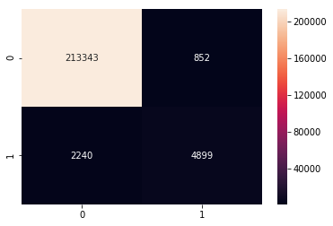

```python
from sklearn.metrics import confusion_matrix
cm = confusion_matrix(y_train, LogisReg.predict(X_train))
sns.heatmap(cm, annot=True, fmt="d")
```